# Cluster Markers and Cell Type Assignment

August 13<sup>th</sup>, 2019

## finding markers and differential expression analysis

After clustering, differential expression testing (DE analysis, similar to bulk RNA seq) finds gene signatures of each cluster/cell population, to give more insights into biology.

### many proposed methods

(for Seurat, we recommend default “wilcox” or “t”, good balances between speed and accuracy)

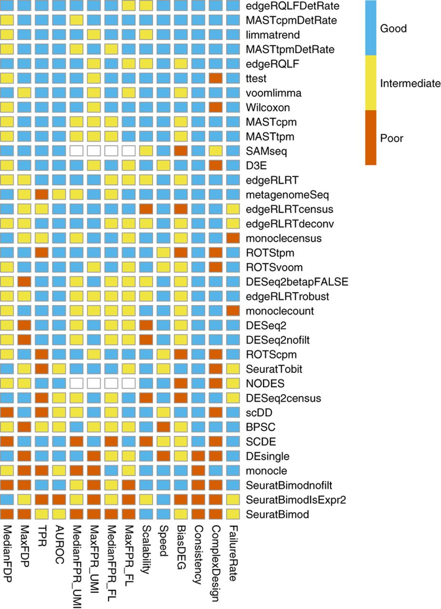

Soneson and Robinson, 2018

### important considerations

1. keep things simple first and look at the results (try not aligning, not regressing)
2. determine what variables to regress out (batch, nCount_RNA, percent_mito, cell cycle, if needed)

```r
library(Seurat)
library(tidyverse)
# load data from saved RDS
sobj <- readRDS("/Users/rf/class/scRNAseq/cellar/vignettes/filtered_sobj.rds")

# log normalize
sobj_l <- NormalizeData(sobj) # <- skip this step if using scran normalization
sobj_l <- ScaleData(sobj_l,
                    vars.to.regress = c("nCount_RNA",
                                        "percent_mito"))

# alternatively, sctransform is a one step normalization and
sobj_sc <- suppressWarnings(SCTransform(object = sobj, # sctransform has some unhelpful warnings
                                        vars.to.regress = c("percent_mito"), # already corrects for transcript number
                                        verbose = FALSE))
```

EXERCISE: How to regress out cell cycle heterogeneity, and do you need to?

```r
# Seurat stores a list of cell cycle specific genes for humans
s.genes <- Seurat::cc.genes$s.genes
g2m.genes <- Seurat::cc.genes$g2m.genes

s.genes
```

```
#>  [1] "MCM5"     "PCNA"     "TYMS"     "FEN1"     "MCM2"     "MCM4"
#>  [7] "RRM1"     "UNG"      "GINS2"    "MCM6"     "CDCA7"    "DTL"
#> [13] "PRIM1"    "UHRF1"    "MLF1IP"   "HELLS"    "RFC2"     "RPA2"
#> [19] "NASP"     "RAD51AP1" "GMNN"     "WDR76"    "SLBP"     "CCNE2"
#> [25] "UBR7"     "POLD3"    "MSH2"     "ATAD2"    "RAD51"    "RRM2"
#> [31] "CDC45"    "CDC6"     "EXO1"     "TIPIN"    "DSCC1"    "BLM"
#> [37] "CASP8AP2" "USP1"     "CLSPN"    "POLA1"    "CHAF1B"   "BRIP1"
#> [43] "E2F8"
```

```r
g2m.genes
```

```
#>  [1] "HMGB2"   "CDK1"    "NUSAP1"  "UBE2C"   "BIRC5"   "TPX2"    "TOP2A"
#>  [8] "NDC80"   "CKS2"    "NUF2"    "CKS1B"   "MKI67"   "TMPO"    "CENPF"
#> [15] "TACC3"   "FAM64A"  "SMC4"    "CCNB2"   "CKAP2L"  "CKAP2"   "AURKB"
#> [22] "BUB1"    "KIF11"   "ANP32E"  "TUBB4B"  "GTSE1"   "KIF20B"  "HJURP"
#> [29] "CDCA3"   "HN1"     "CDC20"   "TTK"     "CDC25C"  "KIF2C"   "RANGAP1"
#> [36] "NCAPD2"  "DLGAP5"  "CDCA2"   "CDCA8"   "ECT2"    "KIF23"   "HMMR"
#> [43] "AURKA"   "PSRC1"   "ANLN"    "LBR"     "CKAP5"   "CENPE"   "CTCF"
#> [50] "NEK2"    "G2E3"    "GAS2L3"  "CBX5"    "CENPA"
```

```r
# score and phase call is added to metadata
sobj_l <- CellCycleScoring(sobj_l,
                           s.features = s.genes,
                           g2m.features = g2m.genes,
                           set.ident = TRUE)
sobj_l@meta.data %>% head()
```

```
#>                  orig.ident nCount_RNA nFeature_RNA percent_mito
#> AAACATACAACCAC-1    control       2419          779    3.0177759
#> AAACATTGAGCTAC-1    control       4901         1350    3.7951438
#> AAACATTGATCAGC-1    control       3145         1127    0.8903021
#> AAACCGTGCTTCCG-1    control       2637          958    1.7444065
#> AAACCGTGTATGCG-1    control        980          521    1.2244898
#> AAACGCACTGGTAC-1    control       2163          781    1.6643551
#>                      S.Score    G2M.Score Phase old.ident
#> AAACATACAACCAC-1  0.09695064 -0.041859679     S   control
#> AAACATTGAGCTAC-1 -0.03602182 -0.066183886    G1   control
#> AAACATTGATCAGC-1 -0.01077713  0.071587658   G2M   control
#> AAACCGTGCTTCCG-1  0.03941209  0.009940563     S   control
#> AAACCGTGTATGCG-1 -0.04030051  0.036478099   G2M   control
#> AAACGCACTGGTAC-1 -0.03468196 -0.103612859    G1   control
```

```r
Idents(sobj_l)[1:10] # peek at active ident, now set to phase
```

```
#> AAACATACAACCAC-1 AAACATTGAGCTAC-1 AAACATTGATCAGC-1 AAACCGTGCTTCCG-1
#>                S               G1              G2M                S
#> AAACCGTGTATGCG-1 AAACGCACTGGTAC-1 AAACGCTGACCAGT-1 AAACGCTGGTTCTT-1
#>              G2M               G1               G1              G2M
#> AAACGCTGTAGCCA-1 AAACGCTGTTTCTG-1
#>               G1                S
#> Levels: G1 G2M S
```

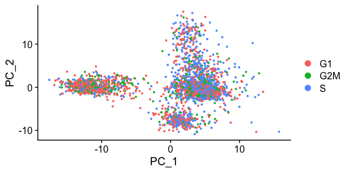

```r
# how would you look at whether cell cycle has strong effects on gene expression?

# how would you regress it out?





# check PCA to see if cell cycle has strong effects
sobj_l <- FindVariableFeatures(sobj_l)
sobj_l <- RunPCA(sobj_l, verbose = FALSE, npcs = 10)
DimPlot(sobj_l, group.by = "Phase") # in this case, cell cycle does not have strong effects
```

```r
# or look for cell cycle-specific genes as main drivers of PCA
topPCAgenes <- apply(
  sobj_l@reductions$pca@feature.loadings, # contribution of each gene to each PC is stored here
  MARGIN = 2,
  FUN = function(x) names(sort(abs(x), decreasing = TRUE)[1:10]) # finds the most important genes in each PC
  )

topPCAgenes
```

```
#>       PC_1     PC_2     PC_3       PC_4        PC_5            PC_6
#>  [1,] "CST3"   "NKG7"   "HLA-DQA1" "PF4"       "CKB"           "GZMK"
#>  [2,] "S100A9" "CST7"   "CD79A"    "SDPR"      "FCGR3A"        "IL32"
#>  [3,] "TYROBP" "GZMA"   "CD79B"    "PPBP"      "MS4A7"         "SPON2"
#>  [4,] "FTL"    "PRF1"   "HLA-DPB1" "HIST1H2AC" "RP11-290F20.3" "GZMB"
#>  [5,] "LST1"   "GZMB"   "CD74"     "GNG11"     "RHOC"          "VIM"
#>  [6,] "FCN1"   "FGFBP2" "HLA-DPA1" "SPARC"     "SIGLEC10"      "S100A4"
#>  [7,] "AIF1"   "GNLY"   "MS4A1"    "GP9"       "LILRA3"        "AKR1C3"
#>  [8,] "LYZ"    "CTSW"   "HLA-DQB1" "NRGN"      "LGALS2"        "B2M"
#>  [9,] "FTH1"   "CD79A"  "HLA-DRB1" "RGS18"     "HMOX1"         "S100A10"
#> [10,] "S100A8" "CCL4"   "PPBP"     "PTCRA"     "MS4A6A"        "CCL5"
#>       PC_7      PC_8       PC_9       PC_10
#>  [1,] "CCL5"    "FCER1A"   "IFIT1"    "IFIT1"
#>  [2,] "GZMK"    "CLEC10A"  "ISG15"    "ISG15"
#>  [3,] "FCER1A"  "ENHO"     "MX1"      "ANXA1"
#>  [4,] "KLRG1"   "SERPINF1" "IFI6"     "PTTG1"
#>  [5,] "CLEC10A" "CD1C"     "GZMK"     "GBP1"
#>  [6,] "SELL"    "GZMK"     "OASL"     "LTB"
#>  [7,] "LYAR"    "RBP7"     "TNFSF10"  "HOPX"
#>  [8,] "NKG7"    "CLIC2"    "ACTG1"    "MX1"
#>  [9,] "AKR1C3"  "S100A12"  "APOBEC3B" "PCNA"
#> [10,] "IFIT1"   "CACNA2D3" "UBE2L6"   "CD27"
```

```r
topPCAgenes %>%
  as.vector() %>%
  intersect(c(s.genes, g2m.genes)) # see how many S and G2M genes intersect with that list
```

```
#> [1] "PCNA"
```

```r
# regress out cell cycle effects
sobj_l <- ScaleData(sobj_l,
                    vars.to.regress = c("nCount_RNA", "percent_mito", "S.Score", "G2M.Score"))

# alternatively, leave the difference of cycling vs noncycling in place, only regress out phases in actively cycling cells
sobj_l$CC.Difference <- sobj_l$S.Score - sobj_l$G2M.Score
sobj_l <- ScaleData(sobj_l,
                    vars.to.regress = c("nCount_RNA",
                                        "percent_mito",
                                        "CC.Difference"))
```

3. use normalized data for DE (slot is dependent on normalization method, also don’t use integrated assay)

```r
# before normalization, "data" slot is the same as counts
sobj@assays$RNA@data[101:105,101:105]
```

```
#> 5 x 5 sparse Matrix of class "dgCMatrix"
#>        AAGATTACAGATCC-1 AAGATTACCCGTTC-1 AAGATTACCGCCTT-1 AAGATTACCTCAAG-1
#> PGD                   2                1                .                .
#> APITD1                .                .                .                .
#> DFFA                  .                .                .                .
#> PEX14                 .                .                .                .
#> CASZ1                 .                .                .                .
#>        AAGATTACTCCTCG-1
#> PGD                   .
#> APITD1                .
#> DFFA                  .
#> PEX14                 .
#> CASZ1                 .
```

```r
# after log normalization, results are stored in "data" slot
sobj_l@assays$RNA@data[101:105,101:105]
```

```
#> 5 x 5 sparse Matrix of class "dgCMatrix"
#>        AAGATTACAGATCC-1 AAGATTACCCGTTC-1 AAGATTACCGCCTT-1 AAGATTACCTCAAG-1
#> PGD            1.780392         1.531085                .                .
#> APITD1         .                .                       .                .
#> DFFA           .                .                       .                .
#> PEX14          .                .                       .                .
#> CASZ1          .                .                       .                .
#>        AAGATTACTCCTCG-1
#> PGD                   .
#> APITD1                .
#> DFFA                  .
#> PEX14                 .
#> CASZ1                 .
```

```r
# after sctransform, results are stored in new assay "SCT"
sobj_sc@assays$SCT@data[101:105,101:105]
```

```
#> 5 x 5 sparse Matrix of class "dgCMatrix"
#>        AAGATTACAGATCC-1 AAGATTACCCGTTC-1 AAGATTACCGCCTT-1 AAGATTACCTCAAG-1
#> PGD           0.6931472        0.6931472                .                .
#> APITD1        .                .                        .                .
#> DFFA          .                .                        .                .
#> PEX14         .                .                        .                .
#> CASZ1         .                .                        .                .
#>        AAGATTACTCCTCG-1
#> PGD                   .
#> APITD1                .
#> DFFA                  .
#> PEX14                 .
#> CASZ1                 .
```

```r
sobj_sc@assays$RNA@data[101:105,101:105] # <- still same as counts, make sure not to use this
```

```
#> 5 x 5 sparse Matrix of class "dgCMatrix"
#>        AAGATTACAGATCC-1 AAGATTACCCGTTC-1 AAGATTACCGCCTT-1 AAGATTACCTCAAG-1
#> PGD                   2                1                .                .
#> APITD1                .                .                .                .
#> DFFA                  .                .                .                .
#> PEX14                 .                .                .                .
#> CASZ1                 .                .                .                .
#>        AAGATTACTCCTCG-1
#> PGD                   .
#> APITD1                .
#> DFFA                  .
#> PEX14                 .
#> CASZ1                 .
```

4. Note that marker genes found is very dependent on clustering and the compared populations
5. P‐values are inflated, due to the cyclic nature of identifyin the same variable genes as markers, which were used for dimension reduction and clustering. However, the ranking of genes based on P‐values is unaffected.

### find all markers for each cluster

`FindAllMarkers` compares cells in each cluster to all other cells in the dataset. Typically, focus is given to genes upregulated in each cluster, ie markers.

```r
# also remember to set ident, or  to the desired comparison
Idents(sobj_l) <- sobj_l@meta.data$Phase
markers_df <- FindAllMarkers(sobj_l,
                             assay = "RNA", # <- would be different for sobj_sc, and intergrated objects would not default to RNA
                             slot = "data",
                             only.pos = TRUE)
markers_df %>% head()
```

```
#>               p_val avg_logFC pct.1 pct.2    p_val_adj cluster   gene
#> LGALS2 1.608392e-10 0.4435051 0.267 0.170 2.022070e-06      G1 LGALS2
#> CST3   3.838069e-10 0.4068795 0.452 0.353 4.825221e-06      G1   CST3
#> CFP    4.851140e-10 0.3592761 0.261 0.165 6.098853e-06      G1    CFP
#> AIF1   2.883878e-09 0.3462756 0.430 0.329 3.625611e-05      G1   AIF1
#> TYMP   2.890856e-09 0.3784967 0.403 0.304 3.634384e-05      G1   TYMP
#> TYROBP 2.127073e-08 0.3628090 0.449 0.355 2.674156e-04      G1 TYROBP
```

### find DE genes for specific cell groups

For more control in the comparisons, use `FindMarkers`. Positive average log (natural) fold change represents higher expression of the gene in cells of `ident.1`.

```r
# DE analysis for 2 clusters
markers_df2 <- FindMarkers(sobj_l,
                           assay = "RNA",
                           slot = "data",
                           ident.1 = "G1",
                           ident.2 = "S",
                           test.use = "t")
markers_df2 %>% head()
```

```
#>             p_val  avg_logFC pct.1 pct.2    p_val_adj
#> RPA2 3.726910e-81 -0.9629314 0.043 0.364 4.685471e-77
#> NASP 2.155646e-39 -0.6236086 0.026 0.201 2.710078e-35
#> SLBP 8.552555e-38 -0.6853847 0.033 0.207 1.075227e-33
#> PCNA 2.641789e-24 -0.5532880 0.013 0.121 3.321258e-20
#> USP1 3.014590e-21 -0.3704380 0.019 0.117 3.789942e-17
#> CST3 1.826168e-19  0.6185125 0.452 0.310 2.295858e-15
```

`FindMarkers` defaults to the current active ident. To use other value groups, set idents to the intended column, or use the `group.by` argument.

```r
# compare control vs treated in only S phased cells
Idents(sobj_l) <- sobj_l@meta.data$Phase
markers_df3 <- FindMarkers(sobj_l,
                           assay = "RNA", # <- would be different for sobj_sc
                           slot = "data",
                           subset.ident = "S", # <- if needed, subset on current ident first, then switch idents
                           group.by = "orig.ident", # <- grouping cells by this metadata column
                           ident.1 = "control",
                           ident.2 = "treated",
                           test.use = "t")
```

Matrix and data.frame manipulation allows for greater control for assigning new idents, and custom DE analysis pairs.

```r
# set new idents for more customized comparisons
Idents(sobj_l,
       WhichCells(object = sobj_l,
                  idents = "G1",
                  expression = ZFP36 > 1,
                  slot = 'data')) <- 'ZFP36.pos'
Idents(sobj_l,
       WhichCells(object = sobj_l,
                  idents = "G1",
                  expression = ZFP36 <= 1,
                  slot = 'data')) <- 'ZFP36.neg'
Idents(sobj_l) %>% head() # note that with this method, some cell idents might not be changed
```

```
#> AAACATACAACCAC-1 AAACATTGAGCTAC-1 AAACATTGATCAGC-1 AAACCGTGCTTCCG-1
#>                S        ZFP36.pos              G2M                S
#> AAACCGTGTATGCG-1 AAACGCACTGGTAC-1
#>              G2M        ZFP36.pos
#> Levels: ZFP36.neg ZFP36.pos G2M S
```

```r
markers_df4 <- FindMarkers(sobj_l,
                           ident.1 = "ZFP36.pos",
                           ident.2 = "ZFP36.neg")
```

Genes of interest can then be visualized as violin plots or feature plots.

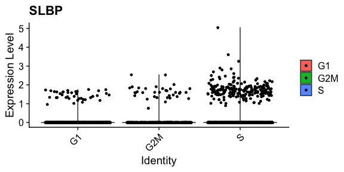

```r
Idents(sobj_l) <- sobj_l@meta.data$Phase # plots are grouped by active ident
VlnPlot(sobj_l, "SLBP")
```

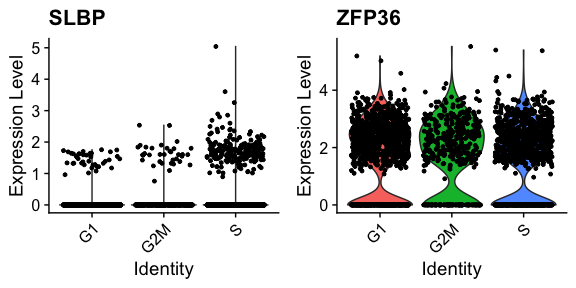

```r
VlnPlot(sobj_l, c("SLBP", "ZFP36")) # can be a vector of gene names
```

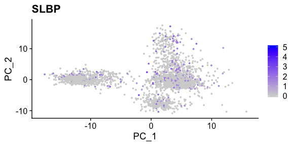

```r
FeaturePlot(sobj_l, "SLBP")
```

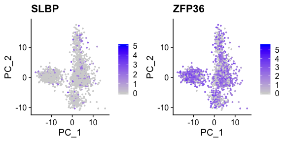

```r
FeaturePlot(sobj_l, c("SLBP", "ZFP36")) # can be a vector of gene names
```

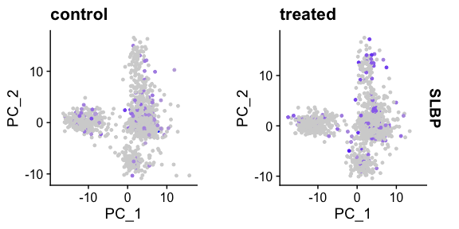

```r
FeaturePlot(sobj_l, "SLBP", split.by = "orig.ident") # <- split into panels based on metadata column
```

## cluster identities

Without venturing into the realm of philosphical debates on what a “cell type” constitutes, standard pratice is to use certain gene expression features to classify cells. This is often done manually, by visual inspection of key genes. Automated approaches that utilize a broader range of features are currently being developed.

### manual check and cluster identity assignment

```r
# from the Seurat pancreas example
# we now have pan_celseq2, fully annotated in metadata column "celltype", and pan_smartseq2, ready to be annotated
pan_celseq2 <- readRDS("pan_celseq2.rds")
pan_celseq2@meta.data %>% head()
```

```
#>             orig.ident nCount_RNA nFeature_RNA    tech celltype
#> D28-1_1  SeuratProject  23438.618         5448 celseq2    alpha
#> D28-1_15 SeuratProject  27252.978         5918 celseq2    alpha
#> D28-1_17 SeuratProject  16177.715         4522 celseq2    alpha
#> D28-1_29 SeuratProject  39356.525         7416 celseq2    alpha
#> D28-1_30 SeuratProject  28958.986         6121 celseq2    alpha
#> D28-1_39 SeuratProject   7389.849         2746 celseq2    alpha
#>          RNA_snn_res.0.8 seurat_clusters
#> D28-1_1                8               8
#> D28-1_15               8               8
#> D28-1_17               0               0
#> D28-1_29               8               8
#> D28-1_30               8               8
#> D28-1_39               0               0
```

```r
pan_smartseq2 <- readRDS("pan_smartseq2.rds")
pan_smartseq2@meta.data %>% head()
```

```
#>           orig.ident nCount_RNA nFeature_RNA      tech celltype
#> AZ_B9  SeuratProject     654549         4433 smartseq2    alpha
#> AZ_A6  SeuratProject     753413         4414 smartseq2    alpha
#> AZ_C1  SeuratProject    2044839         5069 smartseq2    alpha
#> AZ_A11 SeuratProject     705927         3900 smartseq2    alpha
#> AZ_C2  SeuratProject    1338503         5367 smartseq2    alpha
#> AZ_B11 SeuratProject    3378011         7137 smartseq2    alpha
#>        RNA_snn_res.0.8 seurat_clusters
#> AZ_B9               11              11
#> AZ_A6                7               7
#> AZ_C1               11              11
#> AZ_A11              11              11
#> AZ_C2               11              11
#> AZ_B11              11              11
```

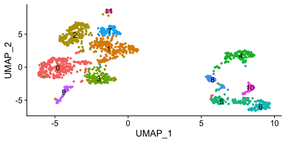

```r
a <- DimPlot(pan_smartseq2, label = TRUE) + NoLegend()
a
```

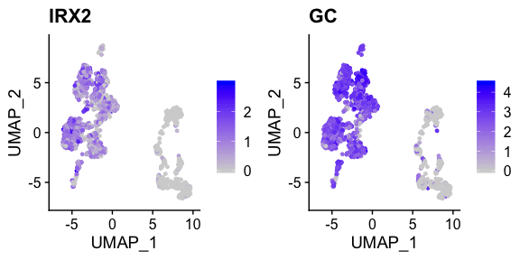

```r
FeaturePlot(pan_smartseq2, c("IRX2","GC"))
```

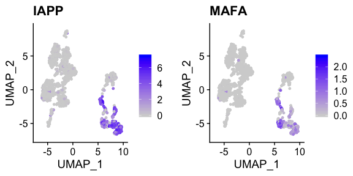

```r
FeaturePlot(pan_smartseq2, c("IAPP","MAFA"))
```

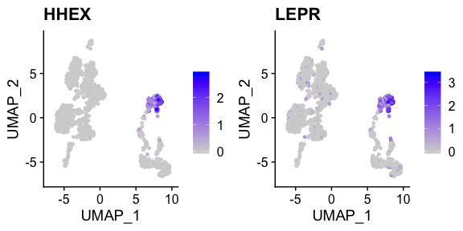

```r
FeaturePlot(pan_smartseq2, c("HHEX","LEPR"))
```

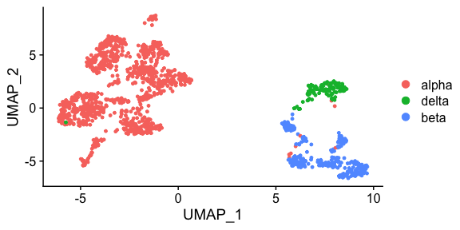

```r
# Create vectors of current cluster IDs and cell type assignments
current.cluster.ids <- c(0,1,2,3,7,9,11, 5,6,8,10, 4)

new.cluster.ids <- c("alpha",
                     "alpha",
                     "alpha",
                     "alpha",
                     "alpha",
                     "alpha",
                     "alpha",
                     "beta",
                     "beta",
                     "beta",
                     "beta",
                     "delta")

# optional, save the cluster numbers as "cluster.id"
pan_smartseq2 <- StashIdent(object = pan_smartseq2, save.name = "cluster.id")

# Use plyr to remap the idents from the current IDs to the new IDs
Idents(pan_smartseq2) <- plyr::mapvalues(x = Idents(pan_smartseq2),
                                         from = current.cluster.ids,
                                         to = new.cluster.ids)

# Plot UMAP with new cluster IDs
DimPlot(object = pan_smartseq2,
        do.label = TRUE)
```

```r
pan_smartseq2 <- StashIdent(object = pan_smartseq2, save.name = "cluster_name")
```

### towards a more automated approach of identity assignment

1. using `Seurat`, inference from previous seurat object (requires very similar seurat object)

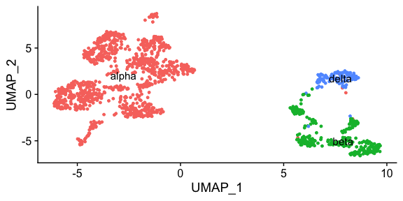

```r
pancreas <- FindTransferAnchors(reference = pan_celseq2, query = pan_smartseq2,
    dims = 1:30)
predictions <- TransferData(anchorset = pancreas, refdata = pan_celseq2$celltype,
    dims = 1:30)
pan_smartseq2 <- AddMetaData(pan_smartseq2, metadata = predictions)
Idents(pan_smartseq2) <- "predicted.id"
DimPlot(pan_smartseq2, label = TRUE) + NoLegend()
```

2. using `clustifyr`, and marker gene list (requires markers or gene list), using gene list enrichment methods

```r
# manually enter gene list
library(clustifyr)
beta <- c("IAPP","MAFA")
alpha <- c("IRX2","GC")
delta <- c("HHEX","LEPR")
genelist <- data.frame(alpha, beta, delta)
genelist
```

```
#>   alpha beta delta
#> 1  IRX2 IAPP  HHEX
#> 2    GC MAFA  LEPR
```

```r
res <- clustify_lists(input = pan_smartseq2@assays$RNA@data,
                      marker = genelist,
                      cluster_info = pan_smartseq2@meta.data$seurat_clusters,
                      method = "jaccard") # calculate jaccard index

res # a matrix of scores
```

```
#>        alpha      beta   delta
#> 0  2.6714700 0.0000000 0.00000
#> 1  0.8017024 0.0000000 0.00000
#> 10 0.0000000 0.8017024 0.00000
#> 11 0.8017024 0.0000000 0.00000
#> 2  2.6714700 0.0000000 0.00000
#> 3  0.8017024 0.0000000 0.00000
#> 4  0.0000000 0.0000000 2.67147
#> 5  0.0000000 0.8017024 0.00000
#> 6  0.0000000 0.8017024 0.00000
#> 7  2.6714700 0.0000000 0.00000
#> 8  0.0000000 0.8017024 0.00000
#> 9  0.8017024 0.0000000 0.00000
```

```r
res2 <- cor_to_call(res, threshold = 0.5) # take the highest, and if lower than cutoff, assign "unknown")
res2 # dataframe of identities
```

```
#> # A tibble: 12 x 3
#> # Groups:   cluster [12]
#>    cluster type      r
#>    <chr>   <chr> <dbl>
#>  1 0       alpha 2.67
#>  2 1       alpha 0.802
#>  3 11      alpha 0.802
#>  4 2       alpha 2.67
#>  5 3       alpha 0.802
#>  6 7       alpha 2.67
#>  7 9       alpha 0.802
#>  8 10      beta  0.802
#>  9 5       beta  0.802
#> 10 6       beta  0.802
#> 11 8       beta  0.802
#> 12 4       delta 2.67
```

```r
newmeta <- pan_smartseq2@meta.data %>% left_join(res2, by = c("seurat_clusters" = "cluster")) %>%
  mutate(type = ifelse(str_detect(type, "r<0.5"), "unknown", type))
pan_smartseq2@meta.data$type <- newmeta$type
DimPlot(pan_smartseq2, label = T, group.by = "type") + NoLegend()
```

[output not shown]

3. using `clustifyr`, and transcriptome profiles (from other scRNAseq, bulk RNAseq, or microarray), using ranked correlation of highly variable genes (scmap is another similar package)

```r
# build a reference from expression matrix data
ref <- average_clusters(mat = pan_celseq2@assays$RNA@data,
                        cluster_info = pan_celseq2@meta.data,
                        cluster_col = "celltype")

res <- clustify(input = pan_smartseq2@assays$RNA@data,
                ref_mat = ref,
                metadata = pan_smartseq2@meta.data,
                query_genes = pan_smartseq2@assays$RNA@var.features, # using Seurat computed variable genes
                cluster_col = "seurat_clusters")
res2 <- cor_to_call(res, threshold = 0.5) # anything below 0.5 correlation are labeled as "unknown"
res2
```

```
#> # A tibble: 12 x 3
#> # Groups:   cluster [12]
#>    cluster type      r
#>    <chr>   <chr> <dbl>
#>  1 0       alpha 0.740
#>  2 1       alpha 0.716
#>  3 11      alpha 0.673
#>  4 2       alpha 0.755
#>  5 3       alpha 0.739
#>  6 7       alpha 0.731
#>  7 9       alpha 0.741
#>  8 10      beta  0.726
#>  9 5       beta  0.787
#> 10 6       beta  0.805
#> 11 8       beta  0.787
#> 12 4       delta 0.801
```

```r
#make new column in metadata
newmeta <- pan_smartseq2@meta.data %>%
  select(-type) %>%
  left_join(res2, by = c("seurat_clusters" = "cluster")) %>%
  mutate(type = ifelse(str_detect(type, "r<0.5"), "unknown", type)) %>%
  mutate(type = str_remove(type, "-Pancreas")) %>%
  mutate(type = as.factor(type))
pan_smartseq2@meta.data$type <- newmeta$type

# look at UMAP
DimPlot(pan_smartseq2, label = T, group.by = "type") + NoLegend()
```

[output not shown]

```r
# clustifyr also takes seurat objects as input directly, finds various needed data, and output another object with identities assigned
ref <- seurat_ref(pan_celseq2,
                  cluster_col = "celltype")

res <- clustify(input = pan_smartseq2,
                ref_mat = ref,
                cluster_col = "seurat_clusters",
                seurat_out = TRUE)

# look at UMAP
DimPlot(pan_smartseq2, label = TRUE, group.by = "type") + NoLegend()
```

[output not shown]

### cell type composition

Insight into different samples can be gained from the proportion of cells that fall into each cell type. Unfortunately, no dedicated tools are available for statistical testing.

```r
tab1 <- sobj_l@meta.data %>% group_by(orig.ident, Phase) %>% tally() # counting up all combinations
tab1
```

```
#> # A tibble: 6 x 3
#> # Groups:   orig.ident [2]
#>   orig.ident Phase     n
#>   <fct>      <fct> <int>
#> 1 control    G1      587
#> 2 control    G2M     213
#> 3 control    S       545
#> 4 treated    G1      598
#> 5 treated    G2M     221
#> 6 treated    S       526
```

```r
tab2 <- tab1 %>% spread(key = Phase, value = n) # spread out into "wide" form
tab2
```

```
#> # A tibble: 2 x 4
#> # Groups:   orig.ident [2]
#>   orig.ident    G1   G2M     S
#>   <fct>      <int> <int> <int>
#> 1 control      587   213   545
#> 2 treated      598   221   526
```

```r
tab3 <- tab1 %>% group_by(orig.ident) %>%
  mutate(n = n/sum(n)) %>% # convert counts to proportions first
  spread(key = Phase, value = n)
tab3
```

```
#> # A tibble: 2 x 4
#> # Groups:   orig.ident [2]
#>   orig.ident    G1   G2M     S
#>   <fct>      <dbl> <dbl> <dbl>
#> 1 control    0.436 0.158 0.405
#> 2 treated    0.445 0.164 0.391
```

## Other things to do with marker genes

1. gene list to pathway activity score, via [`AUCell`](https://github.com/aertslab/AUCell)
2. if TF expression is too low, consider [`SCENIC`](https://github.com/aertslab/SCENIC) for TF activity inference
3. standard GO term enrichment tools [`gProfiler2`](https://biit.cs.ut.ee/gprofiler/page/r), [`enrichR`](https://github.com/wjawaid/enrichR), [`fgsea`](https://github.com/ctlab/fgsea%5D), etc etc